# Week 3: Classical Test Theory

September 25, 2018

## Today

- Teacher Efficacy Discussion
- Classical Test Theory Discussion
- Discussing PLATO Video we Scored

## Roadmap

- Introduce SII and Efficacy Items
- What is a True score?
- What is Domain Sampling?
- Overview of Classical Test Theory
- Standard Errors of Measurement
- Review of Reliability

## Study for Instructional Improvement

- Quasi-Experimental Study of 3 Comprehensive School Reform Programs
- Using year 1 data
- 1,994 teachers across 84 schools

## Teacher Efficacy Items

- ELA, Math and Program Specific
- ELA and Math
  - Most Students can learn what I am supposed to teach (*Expectancy*)
  - By trying different methods, I can affect achievement (*Efficacy*)
  - I feel satisfaction when students learn (*Value*)
- Program
  - I am capable of making changes called by by the program (*Efficacy*)
  - The changes called for by the program help my students achieve (*Expectancy*)
  - I value changes called for by program (*Value*)

## Correlations

[interactive chart not shown]

## What is a True Score?

- Often we want to measure something, but cannot directly observe it
  - e.g. teacher efficacy
- A teacher's score on this 'latent' construct is the *true score*
  - Theoretically postulated and assumed to exist
  - Estimated with average score across items
- We measure something influenced by latent construct and infer a true score on the latent construct

## Domain Sampling

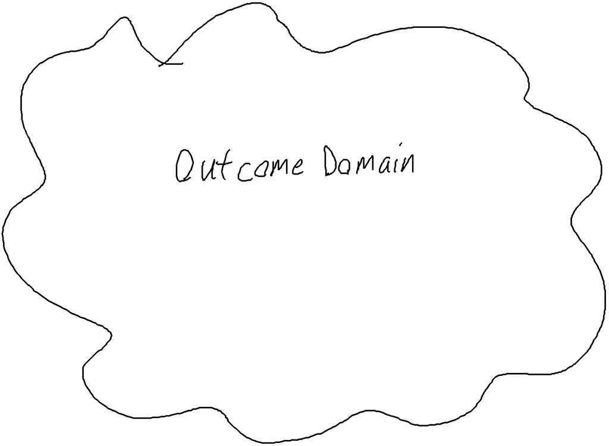

## Domain Sampling

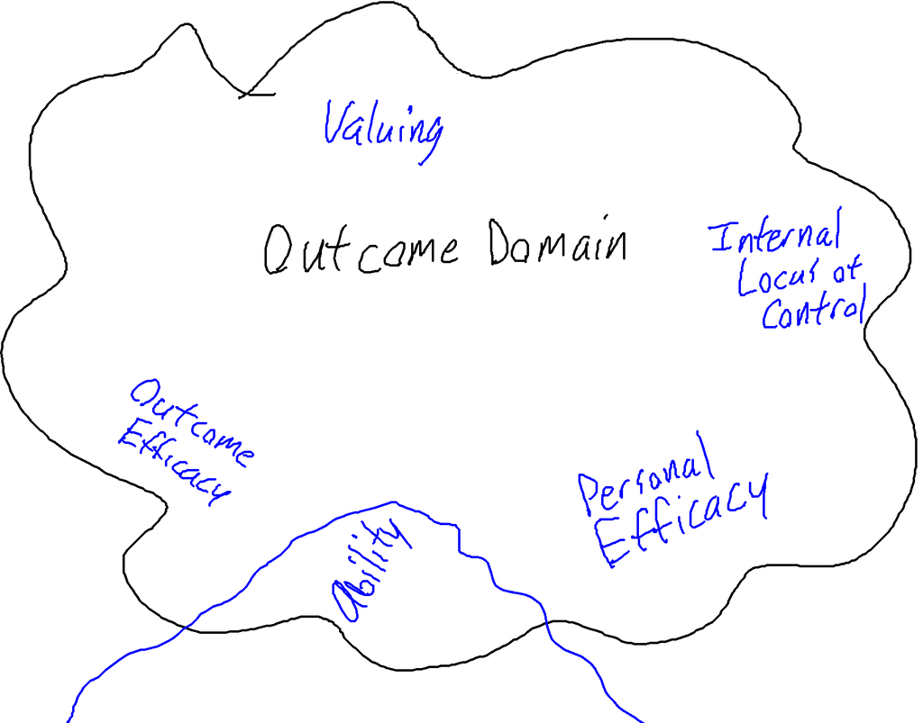

## Classical Test Theory (CTT)

Views Observed Test Score (\(X_i\)) as function of True Score (\(T\)) and Error (\(E_i\)) where \(i\) here indicates items

\[ X_i=T+E_i \]

Assumptions:

- \(E(X_i)=T\) and \(E(E_i)=0\)
- \(cor(E_i,T)=0\)
- \(cor(E_i,E_j)=0\) for \(i \neq j\)
- \(var(E_i)=\sigma_E^2 \ \forall\ i\)

## Reliability Review

\[\begin{aligned} X_i=&T+E_i \\ cor(X_1,X_2) =& \frac{cov(T+E_1,T+E_2)}{\sqrt{var(X_1)*var(X_2)}} \\ =& \frac{cov(T,T) + cov(T,E_2) + cov(T,E_1)+cov(E_1,E_2)}{\sqrt{var(X_1)*var(X_2)}} \\ =& var(T)/var(X) \\ \end{aligned} \]

- Reliability Types
  - Alternate Forms
  - Split Half
  - Alpha (aka internal consistency reliability)
    - not to be confused with internal consistency
  - Test-Retest

## Split-Half Reliability

Generally worth discussing at this point because it led to spearman-brown prophesy formula

\[ r_{sh}=\frac{2*r_{12}}{1+r_{12}} \]

where \(r_{12}\) is correlation between to halves of test

\[ \frac{(n\ items)}{(n\ curr\ items)} = \frac{r_d(1-r_0)}{r_0(1-r_d)} \]

where \(r_d\) is desired reliability and \(r_0\) is observed reliability

## Cronbach's Alpha Reliability

- Many equivalent interpretations
  - Average of all Split-Half Reliabilities
  - Correlation of two tests formed by random items
  - Lower bound to reliability (if not prallel)
- Many Formulas
  - \(\alpha=(m/(m-1))*(1-\sum_i\sigma^2_{X_i}/\sigma^2_X)\)
  - \(\alpha=(m/(m-1))*(\sum_i\sigma_{X_i}/\sigma^2_X)\)
  - \(\alpha=(m*\bar{r})/(1+(m-1)*\bar{r})\)
  - \(\alpha\approx m*\bar{r}/\lambda_1\)

## Alpha in SII

Overall Alpha

```
##  raw_alpha std.alpha average_r     mean        sd
##  0.7894207 0.7911821 0.2962627 4.512941 0.9668748
```

```
##           raw_alpha std.alpha average_r var.r med.r
## ELA_Exp        0.76      0.76      0.29  0.03  0.22
## ELA_Eff        0.75      0.76      0.29  0.03  0.23
## ELA_Value      0.77      0.78      0.31  0.03  0.23
## Mth_Exp        0.75      0.76      0.28  0.03  0.22
## Mth_Eff        0.75      0.76      0.28  0.03  0.23
## Mth_Value      0.77      0.78      0.31  0.03  0.23
## Prg_Exp        0.78      0.77      0.30  0.02  0.25
## Prg_Eff        0.79      0.78      0.31  0.03  0.26
## Prg_Value      0.78      0.78      0.31  0.02  0.26
```

## Alpha in SII

ELA Alpha

```
##  raw_alpha std.alpha average_r     mean        sd
##  0.6849099 0.6878176 0.4234378 5.787006 0.9869159
```

Math Alpha

```
##  raw_alpha std.alpha average_r     mean        sd
##  0.7280344 0.7323844 0.4770515 5.905434 0.9416436
```

Program Alpha

```
##  raw_alpha std.alpha average_r     mean        sd
##  0.8028672 0.8023545 0.5750445 3.011693 0.5617187
```

## Correlations across domains

Standard

```
##            ELA      Math      Prog
## ELA  1.0000000 0.5740066 0.2835422
## Math 0.5740066 1.0000000 0.2318850
## Prog 0.2835422 0.2318850 1.0000000
```

Unattenuated

- Assumes errors are uncorrelated
- Alphas: ELA: 0.69, Math: 0.73, Prog: 0.8
- \(\hat{r_{12}}= r_{12}/sqrt(\alpha_{1}*\alpha_{2})\)

```
##            ELA      Math      Prog
## ELA  1.0000000 0.8087434 0.3816787
## Math 0.8087434 1.0000000 0.3024962
## Prog 0.3816787 0.3024962 1.0000000
```

## Assumption: \(cor(E_i,E_j)=0\ \forall\ i \neq j\)

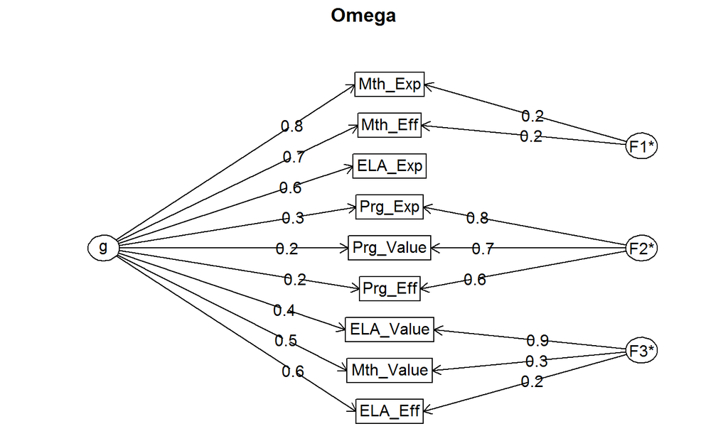

## Assumption: \(var(E_i)=\sigma_E^2 \ \forall\ i\)

```
##           Loadings communality uniquenesses
## ELA_Exp       0.63        0.40         0.60
## ELA_Eff       0.65        0.42         0.58
## ELA_Value     0.49        0.24         0.76
## Mth_Exp       0.66        0.44         0.56
## Mth_Eff       0.68        0.46         0.54
## Mth_Value     0.48        0.23         0.77
## Prg_Exp       0.46        0.21         0.79
## Prg_Eff       0.41        0.17         0.83
## Prg_Value     0.42        0.18         0.82
```

## Standard Error of Measurement (\(se(\hat{T})\))

\[SEM = \sigma_X * \sqrt(1-\alpha)\]

- Alphas: ELA: 0.69, Math: 0.73, Prog: 0.8
- SD: ELA: 0.98, Math: 0.94, Prog: 0.56
- SEM: ELA: 0.55, Math: 0.49, Prog: 0.25

## Expanded CTT -> Factor Analysis

\(X_i=T+E_i\) becomes \(X_i=(\mu_i+\lambda_i*T^{\prime})+E_i\)

- Strictly Parallel becomes Parallel when:
  - \(\mu_i \neq 0\ \forall\ i\)
- Parallel becomes Tau-Equivalent when any of:
  - \(var(E_i)\neq var(E_j)\) for some \(i\neq j\)
  - \(var(X_i)\neq var(X_j)\) for some \(i\neq j\)
- Tau-Equivalent becomes Congeric when:
  - \(\lambda_i \neq \lambda_j\) for some \(i\neq j\)
- In all models:
  - \(E(E_i)=0\)
  - \(cor(E_i,T)=0\)
  - \(cor(E_i,E_j)=0\) for \(i \neq j\)

## Expanded CTT

- Item Response Theory
  - \(X_i=T+E_i\) becomes \(X_i=logit(\mu_i+\lambda_i*T^')\)
  - SEM becomes person specific
  - \(\mu_i\) are interpreted as characteristics of items transferable across populations
- Generalizability Theory
  - \(E_i\) becomes \(E_i=\sum(E_f)_{f\in facet}\)

## Change in True Score Across Time

Note that

- Variance of the Error Doubles in Difference
- Variance of \(T_\delta\) is usually less than variance in \(T\)
  - Hence, true score decreases
- Thus, reliability decreases greatly when examining change in true score across time